# Segmenting_Clustering_Neighborhoods_in_Toronto

## Introduction

**This project is for exploring the neighbourhoods in the city Toronto. Details about neighbourhoods are not readily available from internet sources. So collect the data from Wikipedia page about neighbourhoods and explore that data and created segmentation and cluster the neighbourhoods in Toronto city.**

1. Scrape the Wikipedia page and wrangle the data
2. Clean the data and create data frame as df_cleaned.
3. Take over the geographical coordinates from the given csv file and create new dataframe
4. Explore the venues in the neighbourhoods and perform analysis

```python
import numpy as np # library to handle data in a vectorized manner

import pandas as pd # library for data analsysis
pd.set_option('display.max_columns', None)
pd.set_option('display.max_rows', None)

import json # library to handle JSON files

#!conda install -c conda-forge geopy --yes # uncomment this line if you haven't completed the Foursquare API lab
from geopy.geocoders import Nominatim # convert an address into latitude and longitude values

import requests # library to handle requests
from pandas.io.json import json_normalize # tranform JSON file into a pandas dataframe
from bs4 import BeautifulSoup # for web scrapping

# Matplotlib and associated plotting modules
import matplotlib.cm as cm
import matplotlib.colors as colors
import matplotlib.pyplot as plt

# import k-means from clustering stage
from sklearn.cluster import KMeans
from sklearn.metrics import silhouette_score

#!conda install -c conda-forge folium=0.5.0 --yes # uncomment this line if you haven't completed the Foursquare API lab
import folium # map rendering library

import warnings
warnings.filterwarnings('ignore')

print('Libraries imported.')
```

```
Libraries imported.
```

### 1. Scrape the Wikipedia page and wrangle the data

```python
wiki_url = 'https://en.wikipedia.org/wiki/List_of_postal_codes_of_Canada:_M'
response = requests.get(wiki_url, 'lxml')  # get the data using requests, store in 'response'
print(response)
```

```
<Response [200]>
```

```python
soup = BeautifulSoup(response.text,'lxml') # create a beautiful soup object named 'soup'

# read the table details
table = soup.find('table', {'class':'wikitable sortable'})
my_tbl_data = table.find_all('tr')
my_tbl_data[:5]
```

```
[<tr>
 <th>Postcode</th>
 <th>Borough</th>
 <th>Neighbourhood
 </th></tr>, <tr>
 <td>M1A</td>
 <td>Not assigned</td>
 <td>Not assigned
 </td></tr>, <tr>
 <td>M2A</td>
 <td>Not assigned</td>
 <td>Not assigned
 </td></tr>, <tr>
 <td>M3A</td>
 <td><a href="/wiki/North_York" title="North York">North York</a></td>
 <td><a href="/wiki/Parkwoods" title="Parkwoods">Parkwoods</a>
 </td></tr>, <tr>
 <td>M4A</td>
 <td><a href="/wiki/North_York" title="North York">North York</a></td>
 <td><a href="/wiki/Victoria_Village" title="Victoria Village">Victoria Village</a>
 </td></tr>]
```

```python
# read all table data and store it in a list form
feature_names = []

for i in my_tbl_data:
    loc_feature_name = ' '.join(i.find_all(text=True)).replace('\n','').strip(' ')
    feature_names.append(loc_feature_name)
feature_names[:5]
```

```
['Postcode  Borough  Neighbourhood',
 'M1A  Not assigned  Not assigned',
 'M2A  Not assigned  Not assigned',
 'M3A  North York  Parkwoods',
 'M4A  North York  Victoria Village']
```

```python
# keys (columns) details of webscrapping data
keys_lst = feature_names[0].split('  ')
keys_lst
```

```
['Postcode', 'Borough', 'Neighbourhood']
```

```python
# value details
values_lst = []

for i in feature_names[1:]:
    i = i.split('  ')
    values_lst.append(i)
values_lst[:5]
```

```
[['M1A', 'Not assigned', 'Not assigned'],
 ['M2A', 'Not assigned', 'Not assigned'],
 ['M3A', 'North York', 'Parkwoods'],
 ['M4A', 'North York', 'Victoria Village'],
 ['M5A', 'Downtown Toronto', 'Harbourfront']]
```

```python
# read the all values and store that dat in dict form.
webscrap_dict = {}
loc_key_value = []
for i in range(len(keys_lst)):
    for item in values_lst:
        loc_key_value.append(item[i])
    webscrap_dict[keys_lst[i]] = loc_key_value
    loc_key_value = []
```

```python
# checking the length of the data frame (Webscrap)
len(webscrap_dict['Postcode'])
```

```
287
```

```python
# Create data frame
df_webscrap_data = pd.DataFrame(webscrap_dict)
df_webscrap_data.head()
```

|  | Postcode | Borough | Neighbourhood |
| --- | --- | --- | --- |
| 0 | M1A | Not assigned | Not assigned |
| 1 | M2A | Not assigned | Not assigned |
| 2 | M3A | North York | Parkwoods |
| 3 | M4A | North York | Victoria Village |
| 4 | M5A | Downtown Toronto | Harbourfront |

```python
# check the unique values of 'Borough' columns. It is mentioned in problem statement, we can ignore the 'Not assigned' values.
df_webscrap_data['Borough'].unique()
```

```
array(['Not assigned', 'North York', 'Downtown Toronto', "Queen's Park",
       'Scarborough', 'East York', 'Etobicoke', 'York', 'East Toronto',
       'West Toronto', 'Central Toronto', 'Mississauga'], dtype=object)
```

**Only process the cells that have an assigned borough. Ignore cells with a borough that is Not assigned.**

```python
# remove all rows, having 'Not assigned' value in 'Borough' column.
df = df_webscrap_data[~df_webscrap_data.Borough.str.match('Not assigned')]
df.head()
```

|  | Postcode | Borough | Neighbourhood |
| --- | --- | --- | --- |
| 2 | M3A | North York | Parkwoods |
| 3 | M4A | North York | Victoria Village |
| 4 | M5A | Downtown Toronto | Harbourfront |
| 5 | M6A | North York | Lawrence Heights |
| 6 | M6A | North York | Lawrence Manor |

**If a cell has a borough but a Not assigned neighborhood, then the neighborhood will be the same as the borough.**

```python
# If a cell has a borough but a Not assigned neighborhood, then the neighborhood will be the same as the borough
df.Neighbourhood.replace('Not assigned',df.Borough, inplace = True)
```

```python
# check for missing values in each columns
df.isnull().sum()
```

```
Postcode         0
Borough          0
Neighbourhood    0
dtype: int64
```

```python
# check the unique values from 'Postcode' need to combine the 'Neighbourhood' values of same 'Postcode'
df['Postcode'].value_counts()[:10] # print only top 10 frequent 'Postcode'
```

```
M9V    8
M8Y    8
M5V    7
M9B    5
M4V    5
M8Z    5
M6M    4
M1V    4
M9C    4
M9R    4
Name: Postcode, dtype: int64
```

**More than one neighborhood can exist in one postal code area, so combined into one row with the neighborhoods separated with a comma.**

```python
# combine the 'Neighbourhood' values of same 'Postcode'
df_cleaned = df.groupby(['Postcode', 'Borough'])['Neighbourhood'].apply(','.join).reset_index()
df_cleaned.head()
```

|  | Postcode | Borough | Neighbourhood |
| --- | --- | --- | --- |
| 0 | M1B | Scarborough | Rouge,Malvern |
| 1 | M1C | Scarborough | Highland Creek,Rouge Hill,Port Union |
| 2 | M1E | Scarborough | Guildwood,Morningside,West Hill |
| 3 | M1G | Scarborough | Woburn |
| 4 | M1H | Scarborough | Cedarbrae |

```python
# shape of the final data frame
df_cleaned.shape
```

```
(103, 3)
```

### Get latitude and the logitude coordinates

```python
# get the geographical coordinates from the given csv link
df_coord = pd.read_csv('https://cocl.us/Geospatial_data')
df_coord.head()
```

|  | Postal Code | Latitude | Longitude |
| --- | --- | --- | --- |
| 0 | M1B | 43.806686 | -79.194353 |
| 1 | M1C | 43.784535 | -79.160497 |
| 2 | M1E | 43.763573 | -79.188711 |
| 3 | M1G | 43.770992 | -79.216917 |
| 4 | M1H | 43.773136 | -79.239476 |

```python
# rename the Postal Code with Postcode to perform dataframe merge on Postcode
df_coord.rename(columns = {'Postal Code':'Postcode'}, inplace = True)
```

```python
df_coord.head()
```

|  | Postcode | Latitude | Longitude |
| --- | --- | --- | --- |
| 0 | M1B | 43.806686 | -79.194353 |
| 1 | M1C | 43.784535 | -79.160497 |
| 2 | M1E | 43.763573 | -79.188711 |
| 3 | M1G | 43.770992 | -79.216917 |
| 4 | M1H | 43.773136 | -79.239476 |

```python
# perform inner merge on postcode between the df_cleaned and df_coord.
df_final = df_cleaned.merge(df_coord,how= 'inner', on= 'Postcode')
```

```python
df_final.head(10)
```

|  | Postcode | Borough | Neighbourhood | Latitude | Longitude |
| --- | --- | --- | --- | --- | --- |
| 0 | M1B | Scarborough | Rouge,Malvern | 43.806686 | -79.194353 |
| 1 | M1C | Scarborough | Highland Creek,Rouge Hill,Port Union | 43.784535 | -79.160497 |
| 2 | M1E | Scarborough | Guildwood,Morningside,West Hill | 43.763573 | -79.188711 |
| 3 | M1G | Scarborough | Woburn | 43.770992 | -79.216917 |
| 4 | M1H | Scarborough | Cedarbrae | 43.773136 | -79.239476 |
| 5 | M1J | Scarborough | Scarborough Village | 43.744734 | -79.239476 |
| 6 | M1K | Scarborough | East Birchmount Park,Ionview,Kennedy Park | 43.727929 | -79.262029 |
| 7 | M1L | Scarborough | Clairlea,Golden Mile,Oakridge | 43.711112 | -79.284577 |
| 8 | M1M | Scarborough | Cliffcrest,Cliffside,Scarborough Village West | 43.716316 | -79.239476 |
| 9 | M1N | Scarborough | Birch Cliff,Cliffside West | 43.692657 | -79.264848 |

```python
df_final.shape # shape of the final data frame
```

```
(103, 5)
```

```python
df_final.isnull().sum() # check if there is any missing values.
```

```
Postcode         0
Borough          0
Neighbourhood    0
Latitude         0
Longitude        0
dtype: int64
```

In order to define an instance of the geocoder, we need to define a user_agent. We will name our agent *`to_explorer`*, as shown below.

### Explore the venues in the neighbourhoods

```python
address = 'Toronto,ON,Canada'

geolocator = Nominatim(user_agent="to_explorer")
location = geolocator.geocode(address)
latitude = location.latitude
longitude = location.longitude
print('The geograpical coordinate of Toronto, ON, Canada are {}, {}.'.format(latitude, longitude))
```

```
The geograpical coordinate of Toronto, ON, Canada are 43.653963, -79.387207.
```

### Create a map of Toronto with neighborhoods superimposed on top

```python
# create map of Toronto using latitude and longitude values
map_toronto = folium.Map(location=[latitude, longitude], zoom_start=10)

# add markers to map
for lat, lng, borough, neighborhood in zip(df_final['Latitude'], df_final['Longitude'], df_final['Borough'], df_final['Neighbourhood']):
    label = '{}, {}'.format(neighborhood, borough)
    label = folium.Popup(label, parse_html=True)
    folium.CircleMarker(
        [lat, lng],
        radius=5,
        popup=label,
        color='blue',
        fill=True,
        fill_color='#3186cc',
        fill_opacity=0.7,
        parse_html=False).add_to(map_toronto)

map_toronto
```

[interactive chart not shown]

### Lets explore the neighborhoods using Foursquare API

```python
# Define Foursquare Credentials and Version

CLIENT_ID = 'N5K3MGZFIX4TTB4SIZFUFUTFJ3L4SJW4HWL4FXCLIBA0U0FP' # your Foursquare ID
CLIENT_SECRET = '2YCIIUPPU01IUDRCW5IC4ADGW3T5BBC3M4WJMCDSOY3A3HMY' # your Foursquare Secret
VERSION = '20200223' # Foursquare API version

print('Your credentails:')
print('CLIENT_ID: ' + CLIENT_ID)
print('CLIENT_SECRET:' + CLIENT_SECRET)
```

```
Your credentails:
CLIENT_ID: N5K3MGZFIX4TTB4SIZFUFUTFJ3L4SJW4HWL4FXCLIBA0U0FP
CLIENT_SECRET:2YCIIUPPU01IUDRCW5IC4ADGW3T5BBC3M4WJMCDSOY3A3HMY
```

### Lets explore the first neighborhood in our dataframe : df_final

```python
df_final.loc[0,'Neighbourhood'] # name of the neighbourhood
```

```
'Rouge,Malvern'
```

```python
# get the neighbourhood latitude and logitude values

neighborhood_latitude = df_final.loc[0, 'Latitude'] # neighborhood latitude value
neighborhood_longitude = df_final.loc[0, 'Longitude'] # neighborhood longitude value

neighborhood_name = df_final.loc[0, 'Neighbourhood'] # neighborhood name

print('Latitude and longitude values of {} are {}, {}.'.format(neighborhood_name,
                                                               neighborhood_latitude,
                                                               neighborhood_longitude))
```

```
Latitude and longitude values of Rouge,Malvern are 43.806686299999996, -79.19435340000001.
```

**lets get the top 100 venues that are in Rouge, Malvern within a radius of 500 meters.**

```python
LIMIT = 100 # limit of number of venues returned by Foursquare API

radius = 500 # define radius

url = 'https://api.foursquare.com/v2/venues/explore?&client_id={}&client_secret={}&v={}&ll={},{}&radius={}&limit={}'.format(
    CLIENT_ID,
    CLIENT_SECRET,
    VERSION,
    neighborhood_latitude,
    neighborhood_longitude,
    radius,
    LIMIT)
print(url)
```

```
https://api.foursquare.com/v2/venues/explore?&client_id=N5K3MGZFIX4TTB4SIZFUFUTFJ3L4SJW4HWL4FXCLIBA0U0FP&client_secret=2YCIIUPPU01IUDRCW5IC4ADGW3T5BBC3M4WJMCDSOY3A3HMY&v=20200223&ll=43.806686299999996,-79.19435340000001&radius=500&limit=100
```

```python
# trigger GET request to check the results

results = requests.get(url).json()
results
```

```
{'meta': {'code': 200, 'requestId': '5e5297daaba297001b603327'},
 'response': {'warning': {'text': "There aren't a lot of results near you. Try something more general, reset your filters, or expand the search area."},
  'headerLocation': 'Malvern',
  'headerFullLocation': 'Malvern, Toronto',
  'headerLocationGranularity': 'neighborhood',
  'totalResults': 1,
  'suggestedBounds': {'ne': {'lat': 43.8111863045, 'lng': -79.18812958073042},
   'sw': {'lat': 43.80218629549999, 'lng': -79.2005772192696}},
  'groups': [{'type': 'Recommended Places',
    'name': 'recommended',
    'items': [{'reasons': {'count': 0,
       'items': [{'summary': 'This spot is popular',
         'type': 'general',
         'reasonName': 'globalInteractionReason'}]},
      'venue': {'id': '4bb6b9446edc76b0d771311c',
       'name': "Wendy's",
       'location': {'crossStreet': 'Morningside & Sheppard',
        'lat': 43.80744841934756,
        'lng': -79.19905558052072,
        'labeledLatLngs': [{'label': 'display',
          'lat': 43.80744841934756,
          'lng': -79.19905558052072}],
        'distance': 387,
        'cc': 'CA',
        'city': 'Toronto',
        'state': 'ON',
        'country': 'Canada',
        'formattedAddress': ['Toronto ON', 'Canada']},
       'categories': [{'id': '4bf58dd8d48988d16e941735',
         'name': 'Fast Food Restaurant',
         'pluralName': 'Fast Food Restaurants',
         'shortName': 'Fast Food',
         'icon': {'prefix': 'https://ss3.4sqi.net/img/categories_v2/food/fastfood_',
          'suffix': '.png'},
         'primary': True}],
       'photos': {'count': 0, 'groups': []}},
      'referralId': 'e-0-4bb6b9446edc76b0d771311c-0'}]}]}}
```

From the Foursquare lab in the previous module, we know that all the information is in the *items* key. Before we proceed, let's borrow the **`get_category_type`** function from the Foursquare lab.

```python
# function that extracts the category of the venue
def get_category_type(row):
    try:
        categories_list = row['categories']
    except:
        categories_list = row['venue.categories']

    if len(categories_list) == 0:
        return None
    else:
        return categories_list[0]['name']
```

```python
# clean the json and structure it into a pandas dataframe
venues = results['response']['groups'][0]['items']

nearby_venues = json_normalize(venues) # flatten JSON

# filter columns
filtered_columns = ['venue.name', 'venue.categories', 'venue.location.lat', 'venue.location.lng']
nearby_venues =nearby_venues.loc[:, filtered_columns]

# filter the category for each row
nearby_venues['venue.categories'] = nearby_venues.apply(get_category_type, axis=1)

# clean columns
nearby_venues.columns = [col.split(".")[-1] for col in nearby_venues.columns]

nearby_venues.head()
```

|  | name | categories | lat | lng |
| --- | --- | --- | --- | --- |
| 0 | Wendy's | Fast Food Restaurant | 43.807448 | -79.199056 |

```python
print('{} venues were returned by Foursquare.'.format(nearby_venues.shape[0]))
```

```
1 venues were returned by Foursquare.
```

### Let's create a function to repeat the same process to all the neighborhoods in Toronto

```python
def getNearbyVenues(names, latitudes, longitudes, radius=500):

    venues_list=[]
    for name, lat, lng in zip(names, latitudes, longitudes):
        print(name)

        # create the API request URL
        url = 'https://api.foursquare.com/v2/venues/explore?&client_id={}&client_secret={}&v={}&ll={},{}&radius={}&limit={}'.format(
            CLIENT_ID,
            CLIENT_SECRET,
            VERSION,
            lat,
            lng,
            radius,
            LIMIT)

        # make the GET request
        results = requests.get(url).json()["response"]['groups'][0]['items']

        # return only relevant information for each nearby venue
        venues_list.append([(
            name,
            lat,
            lng,
            v['venue']['name'],
            v['venue']['location']['lat'],
            v['venue']['location']['lng'],
            v['venue']['categories'][0]['name']) for v in results])

    nearby_venues = pd.DataFrame([item for venue_list in venues_list for item in venue_list])
    nearby_venues.columns = ['Neighborhood',
                  'Neighborhood Latitude',
                  'Neighborhood Longitude',
                  'Venue',
                  'Venue Latitude',
                  'Venue Longitude',
                  'Venue Category']

    return(nearby_venues)
```

```python
# use the above function to run for each neighborhood and create a new dataframe
toronto_venues = getNearbyVenues(names=df_final['Neighbourhood'],
                                   latitudes=df_final['Latitude'],
                                   longitudes=df_final['Longitude'])
```

```
Rouge,Malvern
Highland Creek,Rouge Hill,Port Union
Guildwood,Morningside,West Hill
Woburn
Cedarbrae
Scarborough Village
East Birchmount Park,Ionview,Kennedy Park
Clairlea,Golden Mile,Oakridge
Cliffcrest,Cliffside,Scarborough Village West
Birch Cliff,Cliffside West
Dorset Park,Scarborough Town Centre,Wexford Heights
Maryvale,Wexford
Agincourt
Clarks Corners,Sullivan,Tam O'Shanter
Agincourt North,L'Amoreaux East,Milliken,Steeles East
L'Amoreaux West
Upper Rouge
Hillcrest Village
Fairview,Henry Farm,Oriole
Bayview Village
Silver Hills,York Mills
Newtonbrook,Willowdale
Willowdale South
York Mills West
Willowdale West
Parkwoods
Don Mills North
Flemingdon Park,Don Mills South
Bathurst Manor,Downsview North,Wilson Heights
Northwood Park,York University
CFB Toronto,Downsview East
Downsview West
Downsview Central
Downsview Northwest
Victoria Village
Woodbine Gardens,Parkview Hill
Woodbine Heights
The Beaches
Leaside
Thorncliffe Park
```

[output cut: 48 more lines]

```
Humber Bay Shores,Mimico South,New Toronto
Alderwood,Long Branch
The Kingsway,Montgomery Road,Old Mill North
Humber Bay,King's Mill Park,Kingsway Park South East,Mimico NE,Old Mill South,The Queensway East,Royal York South East,Sunnylea
Kingsway Park South West,Mimico NW,The Queensway West,Royal York South West,South of Bloor
Queen's Park
Cloverdale,Islington,Martin Grove,Princess Gardens,West Deane Park
Bloordale Gardens,Eringate,Markland Wood,Old Burnhamthorpe
Humber Summit
Emery,Humberlea
Weston
Westmount
Kingsview Village,Martin Grove Gardens,Richview Gardens,St. Phillips
Albion Gardens,Beaumond Heights,Humbergate,Jamestown,Mount Olive,Silverstone,South Steeles,Thistletown
Northwest
```

```python
print(toronto_venues.shape) # shape of the dataframe
toronto_venues.head() # check the head of the dataframe
```

```
(2236, 7)
```

|  | Neighborhood | Neighborhood Latitude | Neighborhood Longitude | Venue | Venue Latitude | Venue Longitude | Venue Category |
| --- | --- | --- | --- | --- | --- | --- | --- |
| 0 | Rouge,Malvern | 43.806686 | -79.194353 | Wendy's | 43.807448 | -79.199056 | Fast Food Restaurant |
| 1 | Highland Creek,Rouge Hill,Port Union | 43.784535 | -79.160497 | Royal Canadian Legion | 43.782533 | -79.163085 | Bar |
| 2 | Highland Creek,Rouge Hill,Port Union | 43.784535 | -79.160497 | Scarborough Historical Society | 43.788755 | -79.162438 | History Museum |
| 3 | Guildwood,Morningside,West Hill | 43.763573 | -79.188711 | Swiss Chalet Rotisserie & Grill | 43.767697 | -79.189914 | Pizza Place |
| 4 | Guildwood,Morningside,West Hill | 43.763573 | -79.188711 | G & G Electronics | 43.765309 | -79.191537 | Electronics Store |

```python
# count of the Venues for each neighborhood
toronto_venues.groupby('Neighborhood').count()[['Venue']]
```

| Neighborhood | Venue |
| --- | --- |
| Adelaide,King,Richmond | 100 |
| Agincourt | 4 |
| Agincourt North,L'Amoreaux East,Milliken,Steeles East | 2 |
| Albion Gardens,Beaumond Heights,Humbergate,Jamestown,Mount Olive,Silverstone,South Steeles,Thistletown | 9 |
| Alderwood,Long Branch | 11 |
| Bathurst Manor,Downsview North,Wilson Heights | 21 |
| Bayview Village | 4 |
| Bedford Park,Lawrence Manor East | 24 |
| Berczy Park | 56 |
| Birch Cliff,Cliffside West | 4 |
| Bloordale Gardens,Eringate,Markland Wood,Old Burnhamthorpe | 7 |
| Brockton,Exhibition Place,Parkdale Village | 22 |
| Business Reply Mail Processing Centre 969 Eastern | 15 |
| CFB Toronto,Downsview East | 3 |
| CN Tower,Bathurst Quay,Island airport,Harbourfront West,King and Spadina,Railway Lands,South Niagara | 17 |
| Cabbagetown,St. James Town | 49 |
| Caledonia-Fairbanks | 4 |
| Canada Post Gateway Processing Centre | 12 |
| Cedarbrae | 8 |
| Central Bay Street | 82 |
| Chinatown,Grange Park,Kensington Market | 84 |
| Christie | 18 |
| Church and Wellesley | 83 |
| Clairlea,Golden Mile,Oakridge | 9 |
| Clarks Corners,Sullivan,Tam O'Shanter | 13 |
| Cliffcrest,Cliffside,Scarborough Village West | 4 |
| Cloverdale,Islington,Martin Grove,Princess Gardens,West Deane Park | 1 |
| Commerce Court,Victoria Hotel | 100 |
| Davisville | 36 |
| Davisville North | 7 |

[output cut: 70 more lines]

### Lets check out how many unique categories from all the returned venues

```python
print('There are {} uniques categories.'.format(len(toronto_venues['Venue Category'].unique())))
```

```
There are 269 uniques categories.
```

```python
 # create dummy variables from 'Venue Category'
df_temp = pd.get_dummies(toronto_venues[['Venue Category']],prefix="", prefix_sep="")

# noticed that there is a one venue category named Neighborhood, drop the same as it will not useful
df_temp.drop(columns = 'Neighborhood', inplace = True)

# create new dataframe by concating 'Neighborhood' and dummy variables from 'Venue Category'
toronto_onehot = pd.concat([toronto_venues[['Neighborhood']],df_temp], axis =1)
toronto_onehot.head()
```

|  | Neighborhood | Accessories Store | Afghan Restaurant | Airport | Airport Food Court | Airport Gate | Airport Lounge | Airport Service | Airport Terminal | American Restaurant | Antique Shop | Aquarium | Art Gallery | Arts & Crafts Store | Asian Restaurant | Athletics & Sports | Auto Garage | Auto Workshop | BBQ Joint | Baby Store | Bagel Shop | Bakery | Bank | Bar | Baseball Field | Baseball Stadium | Basketball Court | Basketball Stadium | Beach | … |
| --- | --- | --- | --- | --- | --- | --- | --- | --- | --- | --- | --- | --- | --- | --- | --- | --- | --- | --- | --- | --- | --- | --- | --- | --- | --- | --- | --- | --- | --- | --- |
| 0 | Rouge,Malvern | 0 | 0 | 0 | 0 | 0 | 0 | 0 | 0 | 0 | 0 | 0 | 0 | 0 | 0 | 0 | 0 | 0 | 0 | 0 | 0 | 0 | 0 | 0 | 0 | 0 | 0 | 0 | 0 | … |
| 1 | Highland Creek,Rouge Hill,Port Union | 0 | 0 | 0 | 0 | 0 | 0 | 0 | 0 | 0 | 0 | 0 | 0 | 0 | 0 | 0 | 0 | 0 | 0 | 0 | 0 | 0 | 0 | 1 | 0 | 0 | 0 | 0 | 0 | … |
| 2 | Highland Creek,Rouge Hill,Port Union | 0 | 0 | 0 | 0 | 0 | 0 | 0 | 0 | 0 | 0 | 0 | 0 | 0 | 0 | 0 | 0 | 0 | 0 | 0 | 0 | 0 | 0 | 0 | 0 | 0 | 0 | 0 | 0 | … |
| 3 | Guildwood,Morningside,West Hill | 0 | 0 | 0 | 0 | 0 | 0 | 0 | 0 | 0 | 0 | 0 | 0 | 0 | 0 | 0 | 0 | 0 | 0 | 0 | 0 | 0 | 0 | 0 | 0 | 0 | 0 | 0 | 0 | … |
| 4 | Guildwood,Morningside,West Hill | 0 | 0 | 0 | 0 | 0 | 0 | 0 | 0 | 0 | 0 | 0 | 0 | 0 | 0 | 0 | 0 | 0 | 0 | 0 | 0 | 0 | 0 | 0 | 0 | 0 | 0 | 0 | 0 | … |

```python
# check the shape of the 'toronto_onehot' dataframe
toronto_onehot.shape
```

```
(2236, 269)
```

```python
# lets make group rows by neighborhood and by taking the mean of the frequency of occurence of each category

toronto_grouped = toronto_onehot.groupby(by = 'Neighborhood').mean().reset_index()
toronto_grouped.head()
```

|  | Neighborhood | Accessories Store | Afghan Restaurant | Airport | Airport Food Court | Airport Gate | Airport Lounge | Airport Service | Airport Terminal | American Restaurant | Antique Shop | Aquarium | Art Gallery | Arts & Crafts Store | Asian Restaurant | Athletics & Sports | Auto Garage | Auto Workshop | BBQ Joint | Baby Store | Bagel Shop | Bakery | Bank | Bar | Baseball Field | Baseball Stadium | Basketball Court | Basketball Stadium | Beach | … |
| --- | --- | --- | --- | --- | --- | --- | --- | --- | --- | --- | --- | --- | --- | --- | --- | --- | --- | --- | --- | --- | --- | --- | --- | --- | --- | --- | --- | --- | --- | --- |
| 0 | Adelaide,King,Richmond | 0.0 | 0.0 | 0.0 | 0.0 | 0.0 | 0.0 | 0.0 | 0.0 | 0.02 | 0.0 | 0.0 | 0.0 | 0.0 | 0.02 | 0.000000 | 0.0 | 0.0 | 0.0 | 0.0 | 0.0 | 0.03 | 0.0 | 0.04 | 0.0 | 0.0 | 0.0 | 0.0 | 0.0 | … |
| 1 | Agincourt | 0.0 | 0.0 | 0.0 | 0.0 | 0.0 | 0.0 | 0.0 | 0.0 | 0.00 | 0.0 | 0.0 | 0.0 | 0.0 | 0.00 | 0.000000 | 0.0 | 0.0 | 0.0 | 0.0 | 0.0 | 0.00 | 0.0 | 0.00 | 0.0 | 0.0 | 0.0 | 0.0 | 0.0 | … |
| 2 | Agincourt North,L'Amoreaux East,Milliken,Steel... | 0.0 | 0.0 | 0.0 | 0.0 | 0.0 | 0.0 | 0.0 | 0.0 | 0.00 | 0.0 | 0.0 | 0.0 | 0.0 | 0.00 | 0.000000 | 0.0 | 0.0 | 0.0 | 0.0 | 0.0 | 0.00 | 0.0 | 0.00 | 0.0 | 0.0 | 0.0 | 0.0 | 0.0 | … |
| 3 | Albion Gardens,Beaumond Heights,Humbergate,Jam... | 0.0 | 0.0 | 0.0 | 0.0 | 0.0 | 0.0 | 0.0 | 0.0 | 0.00 | 0.0 | 0.0 | 0.0 | 0.0 | 0.00 | 0.000000 | 0.0 | 0.0 | 0.0 | 0.0 | 0.0 | 0.00 | 0.0 | 0.00 | 0.0 | 0.0 | 0.0 | 0.0 | 0.0 | … |
| 4 | Alderwood,Long Branch | 0.0 | 0.0 | 0.0 | 0.0 | 0.0 | 0.0 | 0.0 | 0.0 | 0.00 | 0.0 | 0.0 | 0.0 | 0.0 | 0.00 | 0.090909 | 0.0 | 0.0 | 0.0 | 0.0 | 0.0 | 0.00 | 0.0 | 0.00 | 0.0 | 0.0 | 0.0 | 0.0 | 0.0 | … |

```python
# check shape of the grouped dataframe

toronto_grouped.shape
```

```
(100, 269)
```

```python
# lets check top 5 most venues from each neighborhood

num_top_venues = 5

for hood in toronto_grouped['Neighborhood']:
    print("----"+hood+"----")
    temp = toronto_grouped[toronto_grouped['Neighborhood'] == hood].T.reset_index()
    temp.columns = ['venue','freq']
    temp = temp.iloc[1:]
    temp['freq'] = temp['freq'].astype(float)
    temp = temp.round({'freq': 2})
    print(temp.sort_values('freq', ascending=False).reset_index(drop=True).head(num_top_venues))
    print('\n')
```

```
----Adelaide,King,Richmond----
             venue  freq
0      Coffee Shop  0.06
1             Café  0.04
2              Bar  0.04
3  Thai Restaurant  0.04
4       Restaurant  0.03


----Agincourt----
                       venue  freq
0         Chinese Restaurant  0.25
1             Breakfast Spot  0.25
2                     Lounge  0.25
3  Latin American Restaurant  0.25
4          Accessories Store  0.00


----Agincourt North,L'Amoreaux East,Milliken,Steeles East----
                       venue  freq
0                 Playground   0.5
1                       Park   0.5
2  Middle Eastern Restaurant   0.0
3                      Motel   0.0
4        Monument / Landmark   0.0


----Albion Gardens,Beaumond Heights,Humbergate,Jamestown,Mount Olive,Silverstone,South Steeles,Thistletown----
                  venue  freq
0         Grocery Store  0.22
1  Fast Food Restaurant  0.11
2           Coffee Shop  0.11
3   Fried Chicken Joint  0.11
4            Beer Store  0.11


----Alderwood,Long Branch----
                venue  freq
0         Pizza Place  0.18
1                Pool  0.09
```

[output cut: 843 more lines]

```
              venue  freq
0      Skating Rink  0.22
1       Curling Ice  0.11
2  Asian Restaurant  0.11
3          Pharmacy  0.11
4    Cosmetics Shop  0.11


----York Mills West----
               venue  freq
0               Bank  0.25
1                Bar  0.25
2  Convenience Store  0.25
3               Park  0.25
4  Accessories Store  0.00
```

```python
# lets write a function to sort the venues in descending order
def return_most_common_venues(row, num_top_venues):
    row_categories = row.iloc[1:]
    row_categories_sorted = row_categories.sort_values(ascending=False)

    return row_categories_sorted.index.values[0:num_top_venues]
```

```python
# create new dataframe with top 10 most venues for each neighborhood

num_top_venues = 10

indicators = ['st', 'nd', 'rd']

# create columns according to number of top venues
columns = ['Neighborhood']
for ind in np.arange(num_top_venues):
    try:
        columns.append('{}{} Most Common Venue'.format(ind+1, indicators[ind]))
    except:
        columns.append('{}th Most Common Venue'.format(ind+1))

# create a new dataframe
neighborhoods_venues_sorted = pd.DataFrame(columns=columns)
neighborhoods_venues_sorted['Neighborhood'] = toronto_grouped['Neighborhood']

for ind in np.arange(toronto_grouped.shape[0]):
    neighborhoods_venues_sorted.iloc[ind, 1:] = return_most_common_venues(toronto_grouped.iloc[ind, :], num_top_venues)

neighborhoods_venues_sorted.head()
```

|  | Neighborhood | 1st Most Common Venue | 2nd Most Common Venue | 3rd Most Common Venue | 4th Most Common Venue | 5th Most Common Venue | 6th Most Common Venue | 7th Most Common Venue | 8th Most Common Venue | 9th Most Common Venue | 10th Most Common Venue |
| --- | --- | --- | --- | --- | --- | --- | --- | --- | --- | --- | --- |
| 0 | Adelaide,King,Richmond | Coffee Shop | Café | Thai Restaurant | Bar | Restaurant | Cosmetics Shop | Burger Joint | Steakhouse | Bakery | Sushi Restaurant |
| 1 | Agincourt | Lounge | Chinese Restaurant | Latin American Restaurant | Breakfast Spot | Discount Store | Dog Run | Doner Restaurant | Donut Shop | Drugstore | Eastern European Restaurant |
| 2 | Agincourt North,L'Amoreaux East,Milliken,Steel... | Playground | Park | Yoga Studio | Donut Shop | Dessert Shop | Dim Sum Restaurant | Diner | Discount Store | Dog Run | Doner Restaurant |
| 3 | Albion Gardens,Beaumond Heights,Humbergate,Jam... | Grocery Store | Pizza Place | Fast Food Restaurant | Sandwich Place | Beer Store | Fried Chicken Joint | Coffee Shop | Pharmacy | Dumpling Restaurant | Drugstore |
| 4 | Alderwood,Long Branch | Pizza Place | Pool | Pub | Coffee Shop | Pharmacy | Gym | Sandwich Place | Skating Rink | Dance Studio | Athletics & Sports |

### Modeling : Cluster Neighborhoods

```python
# create new dataframe to perform clustering
toronto_grouped_clustering = toronto_grouped.drop(columns = 'Neighborhood')
```

```python
toronto_grouped_clustering.head()
```

|  | Accessories Store | Afghan Restaurant | Airport | Airport Food Court | Airport Gate | Airport Lounge | Airport Service | Airport Terminal | American Restaurant | Antique Shop | Aquarium | Art Gallery | Arts & Crafts Store | Asian Restaurant | Athletics & Sports | Auto Garage | Auto Workshop | BBQ Joint | Baby Store | Bagel Shop | Bakery | Bank | Bar | Baseball Field | Baseball Stadium | Basketball Court | Basketball Stadium | Beach | Bed & Breakfast | … |
| --- | --- | --- | --- | --- | --- | --- | --- | --- | --- | --- | --- | --- | --- | --- | --- | --- | --- | --- | --- | --- | --- | --- | --- | --- | --- | --- | --- | --- | --- | --- |
| 0 | 0.0 | 0.0 | 0.0 | 0.0 | 0.0 | 0.0 | 0.0 | 0.0 | 0.02 | 0.0 | 0.0 | 0.0 | 0.0 | 0.02 | 0.000000 | 0.0 | 0.0 | 0.0 | 0.0 | 0.0 | 0.03 | 0.0 | 0.04 | 0.0 | 0.0 | 0.0 | 0.0 | 0.0 | 0.0 | … |
| 1 | 0.0 | 0.0 | 0.0 | 0.0 | 0.0 | 0.0 | 0.0 | 0.0 | 0.00 | 0.0 | 0.0 | 0.0 | 0.0 | 0.00 | 0.000000 | 0.0 | 0.0 | 0.0 | 0.0 | 0.0 | 0.00 | 0.0 | 0.00 | 0.0 | 0.0 | 0.0 | 0.0 | 0.0 | 0.0 | … |
| 2 | 0.0 | 0.0 | 0.0 | 0.0 | 0.0 | 0.0 | 0.0 | 0.0 | 0.00 | 0.0 | 0.0 | 0.0 | 0.0 | 0.00 | 0.000000 | 0.0 | 0.0 | 0.0 | 0.0 | 0.0 | 0.00 | 0.0 | 0.00 | 0.0 | 0.0 | 0.0 | 0.0 | 0.0 | 0.0 | … |
| 3 | 0.0 | 0.0 | 0.0 | 0.0 | 0.0 | 0.0 | 0.0 | 0.0 | 0.00 | 0.0 | 0.0 | 0.0 | 0.0 | 0.00 | 0.000000 | 0.0 | 0.0 | 0.0 | 0.0 | 0.0 | 0.00 | 0.0 | 0.00 | 0.0 | 0.0 | 0.0 | 0.0 | 0.0 | 0.0 | … |
| 4 | 0.0 | 0.0 | 0.0 | 0.0 | 0.0 | 0.0 | 0.0 | 0.0 | 0.00 | 0.0 | 0.0 | 0.0 | 0.0 | 0.00 | 0.090909 | 0.0 | 0.0 | 0.0 | 0.0 | 0.0 | 0.00 | 0.0 | 0.00 | 0.0 | 0.0 | 0.0 | 0.0 | 0.0 | 0.0 | … |

### Lets check how much this dataframe is good for clustering with Hopkins test.

```python
from sklearn.neighbors import NearestNeighbors
from random import sample
from numpy.random import uniform
import numpy as np
from math import isnan

def hopkins(X):
    d = X.shape[1]
    #d = len(vars) # columns
    n = len(X) # rows
    m = int(0.1 * n)
    nbrs = NearestNeighbors(n_neighbors=1).fit(X.values)

    rand_X = sample(range(0, n, 1), m)

    ujd = []
    wjd = []
    for j in range(0, m):
        u_dist, _ = nbrs.kneighbors(uniform(np.amin(X,axis=0),np.amax(X,axis=0),d).reshape(1, -1), 2, return_distance=True)
        ujd.append(u_dist[0][1])
        w_dist, _ = nbrs.kneighbors(X.iloc[rand_X[j]].values.reshape(1, -1), 2, return_distance=True)
        wjd.append(w_dist[0][1])

    H = sum(ujd) / (sum(ujd) + sum(wjd))
    if isnan(H):
        print(ujd, wjd)
        H = 0

    return H
```

```python
#Use the Hopkins Statistic function to check how good the above data frame to make clusters.
hopkins(toronto_grouped_clustering)
```

```
0.8377607288618825
```

**This dataframe having good hopkins test result, which is a good sign to have good clusters**

### Let's try to figure out how many clusters are good to consider, for this i have choosed elbow curve and avg.silhouette score.

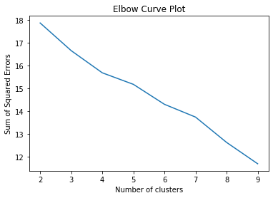

```python
# elbow-curve/SSD
ssd = []
range_n_clusters = range(2,10)
for num_clusters in range_n_clusters:
    kmeans = KMeans(n_clusters=num_clusters, max_iter=50, random_state=42)
    kmeans.fit(toronto_grouped_clustering)

    ssd.append(kmeans.inertia_)

# plot the SSDs for each n_clusters
# ssd
#plt.plot(ssd)
plt.plot(pd.DataFrame(ssd,range_n_clusters))
#plt.text(3,280,'3 clusters are good to consider',fontsize=11)
plt.ylabel('Sum of Squared Errors')
plt.xlabel('Number of clusters')
plt.title('Elbow Curve Plot')
plt.show()
```

```python
# silhouette analysis
range_n_clusters = range(2,10)

for num_clusters in range_n_clusters:

    # intialise kmeans
    kmeans = KMeans(n_clusters=num_clusters, max_iter=50, random_state = 42)
    kmeans.fit(toronto_grouped_clustering)

    cluster_labels = kmeans.labels_

    # silhouette score
    silhouette_avg = silhouette_score(toronto_grouped_clustering, cluster_labels)
    print("For n_clusters={0}, the silhouette score is {1}".format(num_clusters, silhouette_avg))
```

```
For n_clusters=2, the silhouette score is 0.2117420749875925
For n_clusters=3, the silhouette score is 0.22949377275628804
For n_clusters=4, the silhouette score is 0.2518682009714691
For n_clusters=5, the silhouette score is 0.254362293649884
For n_clusters=6, the silhouette score is 0.2672125233197563
For n_clusters=7, the silhouette score is 0.17868173972400964
For n_clusters=8, the silhouette score is 0.23891801750383465
For n_clusters=9, the silhouette score is 0.246252512366602
```

```python
# set number of clusters
kclusters = 4

# run k-means clustering
kmeans = KMeans(n_clusters=kclusters, random_state=42).fit(toronto_grouped_clustering)

# check cluster labels generated for each row in the dataframe
kmeans.labels_[0:10]
```

```
array([0, 0, 3, 0, 0, 0, 0, 0, 0, 0])
```

```python
# lets create
df_final.head()
```

|  | Postcode | Borough | Neighbourhood | Latitude | Longitude |
| --- | --- | --- | --- | --- | --- |
| 0 | M1B | Scarborough | Rouge,Malvern | 43.806686 | -79.194353 |
| 1 | M1C | Scarborough | Highland Creek,Rouge Hill,Port Union | 43.784535 | -79.160497 |
| 2 | M1E | Scarborough | Guildwood,Morningside,West Hill | 43.763573 | -79.188711 |
| 3 | M1G | Scarborough | Woburn | 43.770992 | -79.216917 |
| 4 | M1H | Scarborough | Cedarbrae | 43.773136 | -79.239476 |

```python
# rename the 'Neighbourhood' column name to 'Neighborhood' to make the column name (on which we are going to perfom join)
# of two dataframes are same.
df_final.rename(columns = {'Neighbourhood':'Neighborhood'}, inplace = True)
df_final.head()
```

|  | Postcode | Borough | Neighborhood | Latitude | Longitude |
| --- | --- | --- | --- | --- | --- |
| 0 | M1B | Scarborough | Rouge,Malvern | 43.806686 | -79.194353 |
| 1 | M1C | Scarborough | Highland Creek,Rouge Hill,Port Union | 43.784535 | -79.160497 |
| 2 | M1E | Scarborough | Guildwood,Morningside,West Hill | 43.763573 | -79.188711 |
| 3 | M1G | Scarborough | Woburn | 43.770992 | -79.216917 |
| 4 | M1H | Scarborough | Cedarbrae | 43.773136 | -79.239476 |

```python
neighborhoods_venues_sorted.head()
```

|  | Neighborhood | 1st Most Common Venue | 2nd Most Common Venue | 3rd Most Common Venue | 4th Most Common Venue | 5th Most Common Venue | 6th Most Common Venue | 7th Most Common Venue | 8th Most Common Venue | 9th Most Common Venue | 10th Most Common Venue |
| --- | --- | --- | --- | --- | --- | --- | --- | --- | --- | --- | --- |
| 0 | Adelaide,King,Richmond | Coffee Shop | Café | Thai Restaurant | Bar | Restaurant | Cosmetics Shop | Burger Joint | Steakhouse | Bakery | Sushi Restaurant |
| 1 | Agincourt | Lounge | Chinese Restaurant | Latin American Restaurant | Breakfast Spot | Discount Store | Dog Run | Doner Restaurant | Donut Shop | Drugstore | Eastern European Restaurant |
| 2 | Agincourt North,L'Amoreaux East,Milliken,Steel... | Playground | Park | Yoga Studio | Donut Shop | Dessert Shop | Dim Sum Restaurant | Diner | Discount Store | Dog Run | Doner Restaurant |
| 3 | Albion Gardens,Beaumond Heights,Humbergate,Jam... | Grocery Store | Pizza Place | Fast Food Restaurant | Sandwich Place | Beer Store | Fried Chicken Joint | Coffee Shop | Pharmacy | Dumpling Restaurant | Drugstore |
| 4 | Alderwood,Long Branch | Pizza Place | Pool | Pub | Coffee Shop | Pharmacy | Gym | Sandwich Place | Skating Rink | Dance Studio | Athletics & Sports |

```python
# add clustering labels
neighborhoods_venues_sorted.insert(0, 'Cluster Labels', kmeans.labels_)

toronto_merged = df_final

# merge toronto_grouped with toronto_data to add latitude/longitude for each neighborhood
toronto_merged = toronto_merged.join(neighborhoods_venues_sorted.set_index('Neighborhood'), on='Neighborhood', how = 'inner')

toronto_merged.head() # check head of the new dataframe
```

|  | Postcode | Borough | Neighborhood | Latitude | Longitude | Cluster Labels | 1st Most Common Venue | 2nd Most Common Venue | 3rd Most Common Venue | 4th Most Common Venue | 5th Most Common Venue | 6th Most Common Venue | 7th Most Common Venue | 8th Most Common Venue | 9th Most Common Venue | 10th Most Common Venue |
| --- | --- | --- | --- | --- | --- | --- | --- | --- | --- | --- | --- | --- | --- | --- | --- | --- |
| 0 | M1B | Scarborough | Rouge,Malvern | 43.806686 | -79.194353 | 0 | Fast Food Restaurant | Donut Shop | Dessert Shop | Dim Sum Restaurant | Diner | Discount Store | Dog Run | Doner Restaurant | Yoga Studio | Department Store |
| 1 | M1C | Scarborough | Highland Creek,Rouge Hill,Port Union | 43.784535 | -79.160497 | 0 | History Museum | Bar | Yoga Studio | Drugstore | Diner | Discount Store | Dog Run | Doner Restaurant | Donut Shop | Dumpling Restaurant |
| 2 | M1E | Scarborough | Guildwood,Morningside,West Hill | 43.763573 | -79.188711 | 0 | Medical Center | Spa | Pizza Place | Electronics Store | Breakfast Spot | Intersection | Rental Car Location | Mexican Restaurant | Dog Run | Diner |
| 3 | M1G | Scarborough | Woburn | 43.770992 | -79.216917 | 0 | Coffee Shop | Korean Restaurant | Dumpling Restaurant | Diner | Discount Store | Dog Run | Doner Restaurant | Donut Shop | Drugstore | Yoga Studio |
| 4 | M1H | Scarborough | Cedarbrae | 43.773136 | -79.239476 | 0 | Bank | Fried Chicken Joint | Hakka Restaurant | Thai Restaurant | Athletics & Sports | Caribbean Restaurant | Gas Station | Bakery | Discount Store | Dim Sum Restaurant |

```python
# lets visualize the results of cluters

# create map
map_clusters = folium.Map(location=[latitude, longitude], zoom_start=11)

# set color scheme for the clusters
x = np.arange(kclusters)
ys = [i + x + (i*x)**2 for i in range(kclusters)]
colors_array = cm.gist_rainbow(np.linspace(0, 1, len(ys)))
rainbow = [colors.rgb2hex(i) for i in colors_array]

# add markers to the map
markers_colors = []
for lat, lon, poi, cluster in zip(toronto_merged['Latitude'], toronto_merged['Longitude'], toronto_merged['Neighborhood'], toronto_merged['Cluster Labels']):
    label = folium.Popup(str(poi) + ' Cluster ' + str(cluster), parse_html=True)
    folium.CircleMarker(
        [lat, lon],
        radius=5,
        popup=label,
        color=rainbow[cluster-1],
        fill=True,
        fill_color=rainbow[cluster-1],
        fill_opacity=0.7).add_to(map_clusters)

map_clusters
```

[interactive chart not shown]

### Examine the clusters

```python
# Cluster1

toronto_merged.loc[toronto_merged['Cluster Labels'] == 0, toronto_merged.columns[[1] + list(range(5,
                                                                                                  toronto_merged.shape[1]))]]
```

|  | Borough | Cluster Labels | 1st Most Common Venue | 2nd Most Common Venue | 3rd Most Common Venue | 4th Most Common Venue | 5th Most Common Venue | 6th Most Common Venue | 7th Most Common Venue | 8th Most Common Venue | 9th Most Common Venue | 10th Most Common Venue |
| --- | --- | --- | --- | --- | --- | --- | --- | --- | --- | --- | --- | --- |
| 0 | Scarborough | 0 | Fast Food Restaurant | Donut Shop | Dessert Shop | Dim Sum Restaurant | Diner | Discount Store | Dog Run | Doner Restaurant | Yoga Studio | Department Store |
| 1 | Scarborough | 0 | History Museum | Bar | Yoga Studio | Drugstore | Diner | Discount Store | Dog Run | Doner Restaurant | Donut Shop | Dumpling Restaurant |
| 2 | Scarborough | 0 | Medical Center | Spa | Pizza Place | Electronics Store | Breakfast Spot | Intersection | Rental Car Location | Mexican Restaurant | Dog Run | Diner |
| 3 | Scarborough | 0 | Coffee Shop | Korean Restaurant | Dumpling Restaurant | Diner | Discount Store | Dog Run | Doner Restaurant | Donut Shop | Drugstore | Yoga Studio |
| 4 | Scarborough | 0 | Bank | Fried Chicken Joint | Hakka Restaurant | Thai Restaurant | Athletics & Sports | Caribbean Restaurant | Gas Station | Bakery | Discount Store | Dim Sum Restaurant |
| 5 | Scarborough | 0 | Spa | Playground | Drugstore | Dim Sum Restaurant | Diner | Discount Store | Dog Run | Doner Restaurant | Donut Shop | Dumpling Restaurant |
| 6 | Scarborough | 0 | Discount Store | Coffee Shop | Bus Station | Hobby Shop | Department Store | Yoga Studio | Doner Restaurant | Dim Sum Restaurant | Diner | Dog Run |
| 7 | Scarborough | 0 | Bakery | Bus Line | Soccer Field | Park | Ice Cream Shop | Intersection | Bus Station | Doner Restaurant | Discount Store | Dog Run |
| 8 | Scarborough | 0 | Motel | Movie Theater | American Restaurant | Dessert Shop | Dim Sum Restaurant | Diner | Discount Store | Dog Run | Doner Restaurant | Donut Shop |
| 9 | Scarborough | 0 | General Entertainment | College Stadium | Café | Skating Rink | Yoga Studio | Dim Sum Restaurant | Diner | Discount Store | Dog Run | Doner Restaurant |
| 10 | Scarborough | 0 | Indian Restaurant | Brewery | Chinese Restaurant | Vietnamese Restaurant | Pet Store | Eastern European Restaurant | Electronics Store | Dumpling Restaurant | Drugstore | Deli / Bodega |
| 11 | Scarborough | 0 | Auto Garage | Breakfast Spot | Bakery | Middle Eastern Restaurant | Vietnamese Restaurant | Shopping Mall | Sandwich Place | Yoga Studio | Doner Restaurant | Discount Store |
| 12 | Scarborough | 0 | Lounge | Chinese Restaurant | Latin American Restaurant | Breakfast Spot | Discount Store | Dog Run | Doner Restaurant | Donut Shop | Drugstore | Eastern European Restaurant |
| 13 | Scarborough | 0 | Pharmacy | Pizza Place | Fried Chicken Joint | Noodle House | Italian Restaurant | Thai Restaurant | Chinese Restaurant | Gas Station | Shopping Mall | Fast Food Restaurant |
| 15 | Scarborough | 0 | Fast Food Restaurant | Chinese Restaurant | Coffee Shop | Grocery Store | Electronics Store | Supermarket | Cosmetics Shop | Noodle House | Bubble Tea Shop | Pizza Place |
| 17 | North York | 0 | Fast Food Restaurant | Golf Course | Pool | Mediterranean Restaurant | Dog Run | Yoga Studio | Donut Shop | Dim Sum Restaurant | Diner | Discount Store |
| 18 | North York | 0 | Clothing Store | Coffee Shop | Fast Food Restaurant | Restaurant | Japanese Restaurant | Juice Bar | Tea Room | Women's Store | Bakery | Liquor Store |
| 19 | North York | 0 | Café | Bank | Japanese Restaurant | Chinese Restaurant | Yoga Studio | Dim Sum Restaurant | Discount Store | Dog Run | Doner Restaurant | Donut Shop |
| 22 | North York | 0 | Ramen Restaurant | Café | Restaurant | Coffee Shop | Sandwich Place | Pizza Place | Japanese Restaurant | Sushi Restaurant | Ice Cream Shop | Steakhouse |
| 24 | North York | 0 | Pizza Place | Coffee Shop | Discount Store | Butcher | Pharmacy | Grocery Store | Colombian Restaurant | Dessert Shop | Event Space | Ethiopian Restaurant |
| 25 | North York | 0 | Fast Food Restaurant | Park | Food & Drink Shop | Bus Stop | Ethiopian Restaurant | Electronics Store | Eastern European Restaurant | Dumpling Restaurant | Dessert Shop | Donut Shop |
| 26 | North York | 0 | Gym / Fitness Center | Café | Japanese Restaurant | Caribbean Restaurant | Baseball Field | Dim Sum Restaurant | Discount Store | Dog Run | Doner Restaurant | Donut Shop |
| 27 | North York | 0 | Coffee Shop | Gym | Restaurant | Asian Restaurant | Beer Store | Sporting Goods Shop | Discount Store | Japanese Restaurant | Bike Shop | Sandwich Place |
| 28 | North York | 0 | Coffee Shop | Pharmacy | Frozen Yogurt Shop | Bridal Shop | Diner | Sandwich Place | Deli / Bodega | Restaurant | Middle Eastern Restaurant | Supermarket |
| 29 | North York | 0 | Massage Studio | Coffee Shop | Bar | Caribbean Restaurant | Yoga Studio | Donut Shop | Diner | Discount Store | Dog Run | Doner Restaurant |
| 31 | North York | 0 | Shopping Mall | Grocery Store | Park | Bank | Hotel | Doner Restaurant | Dim Sum Restaurant | Diner | Discount Store | Dog Run |
| 32 | North York | 0 | Baseball Field | Food Truck | Home Service | Yoga Studio | Donut Shop | Diner | Discount Store | Dog Run | Doner Restaurant | Drugstore |
| 33 | North York | 0 | Gym / Fitness Center | Liquor Store | Grocery Store | Coffee Shop | Donut Shop | Dim Sum Restaurant | Diner | Discount Store | Dog Run | Doner Restaurant |
| 34 | North York | 0 | Coffee Shop | French Restaurant | Portuguese Restaurant | Hockey Arena | Yoga Studio | Donut Shop | Dim Sum Restaurant | Diner | Discount Store | Dog Run |
| 35 | East York | 0 | Pizza Place | Gastropub | Fast Food Restaurant | Intersection | Breakfast Spot | Athletics & Sports | Bus Line | Bank | Gym / Fitness Center | Pharmacy |

[output cut: 58 more lines]

```python
# Cluster2

toronto_merged.loc[toronto_merged['Cluster Labels'] == 1, toronto_merged.columns[[1] + list(range(5,
                                                                                                  toronto_merged.shape[1]))]]
```

|  | Borough | Cluster Labels | 1st Most Common Venue | 2nd Most Common Venue | 3rd Most Common Venue | 4th Most Common Venue | 5th Most Common Venue | 6th Most Common Venue | 7th Most Common Venue | 8th Most Common Venue | 9th Most Common Venue | 10th Most Common Venue |
| --- | --- | --- | --- | --- | --- | --- | --- | --- | --- | --- | --- | --- |
| 20 | North York | 1 | Cafeteria | Department Store | Falafel Restaurant | Event Space | Ethiopian Restaurant | Electronics Store | Eastern European Restaurant | Dumpling Restaurant | Drugstore | Donut Shop |

```python
# Cluster3

toronto_merged.loc[toronto_merged['Cluster Labels'] == 2, toronto_merged.columns[[1] + list(range(5,
                                                                                                  toronto_merged.shape[1]))]]
```

|  | Borough | Cluster Labels | 1st Most Common Venue | 2nd Most Common Venue | 3rd Most Common Venue | 4th Most Common Venue | 5th Most Common Venue | 6th Most Common Venue | 7th Most Common Venue | 8th Most Common Venue | 9th Most Common Venue | 10th Most Common Venue |
| --- | --- | --- | --- | --- | --- | --- | --- | --- | --- | --- | --- | --- |
| 91 | Etobicoke | 2 | Construction & Landscaping | Baseball Field | Yoga Studio | Dumpling Restaurant | Discount Store | Dog Run | Doner Restaurant | Donut Shop | Drugstore | Eastern European Restaurant |
| 97 | North York | 2 | Baseball Field | Yoga Studio | Drugstore | Diner | Discount Store | Dog Run | Doner Restaurant | Donut Shop | Dumpling Restaurant | Field |

```python
# Cluster4

toronto_merged.loc[toronto_merged['Cluster Labels'] == 3, toronto_merged.columns[[1] + list(range(5,
                                                                                                  toronto_merged.shape[1]))]]
```

|  | Borough | Cluster Labels | 1st Most Common Venue | 2nd Most Common Venue | 3rd Most Common Venue | 4th Most Common Venue | 5th Most Common Venue | 6th Most Common Venue | 7th Most Common Venue | 8th Most Common Venue | 9th Most Common Venue | 10th Most Common Venue |
| --- | --- | --- | --- | --- | --- | --- | --- | --- | --- | --- | --- | --- |
| 14 | Scarborough | 3 | Playground | Park | Yoga Studio | Donut Shop | Dessert Shop | Dim Sum Restaurant | Diner | Discount Store | Dog Run | Doner Restaurant |
| 23 | North York | 3 | Bank | Park | Bar | Convenience Store | Yoga Studio | Drugstore | Discount Store | Dog Run | Doner Restaurant | Donut Shop |
| 30 | North York | 3 | Airport | Park | Snack Place | Yoga Studio | Donut Shop | Dim Sum Restaurant | Diner | Discount Store | Dog Run | Doner Restaurant |
| 40 | East York | 3 | Convenience Store | Park | Yoga Studio | Dim Sum Restaurant | Diner | Discount Store | Dog Run | Doner Restaurant | Donut Shop | Drugstore |
| 48 | Central Toronto | 3 | Tennis Court | Park | Playground | Restaurant | Dog Run | Department Store | Dessert Shop | Dim Sum Restaurant | Diner | Discount Store |
| 50 | Downtown Toronto | 3 | Park | Playground | Trail | Yoga Studio | Doner Restaurant | Dessert Shop | Dim Sum Restaurant | Diner | Discount Store | Dog Run |
| 73 | York | 3 | Trail | Field | Park | Hockey Arena | Yoga Studio | Dessert Shop | Dim Sum Restaurant | Diner | Discount Store | Dog Run |
| 74 | York | 3 | Park | Market | Pool | Yoga Studio | Doner Restaurant | Dessert Shop | Dim Sum Restaurant | Diner | Discount Store | Dog Run |
| 90 | Etobicoke | 3 | Park | River | Smoke Shop | Yoga Studio | Doner Restaurant | Dessert Shop | Dim Sum Restaurant | Diner | Discount Store | Dog Run |
| 98 | York | 3 | Convenience Store | Park | Yoga Studio | Dim Sum Restaurant | Diner | Discount Store | Dog Run | Doner Restaurant | Donut Shop | Drugstore |